# Tugas P5 MPDW

Author

Indah Dzulkharifah

# White Noise

data berpola AR, MA, ARMA, dan banyak proses deret waktu lainnya diawali pembangkitan *white noise*. *White noise* merupakan sederet nilai dari peubah bebas stokastik identik. Oleh karena itu, *white noise* memiliki dua karakteristik penting:

1. *White noise* tidak memiliki autokorelasi (**karena saling bebas**)
2. Nilai harapan dan ragam *white noise* sama (**karena berasal dari peubah acak bebas stokastik identik**)

*White noise* dibangkitkan dari suatu peubah acak, umumnya peubah acak normal.

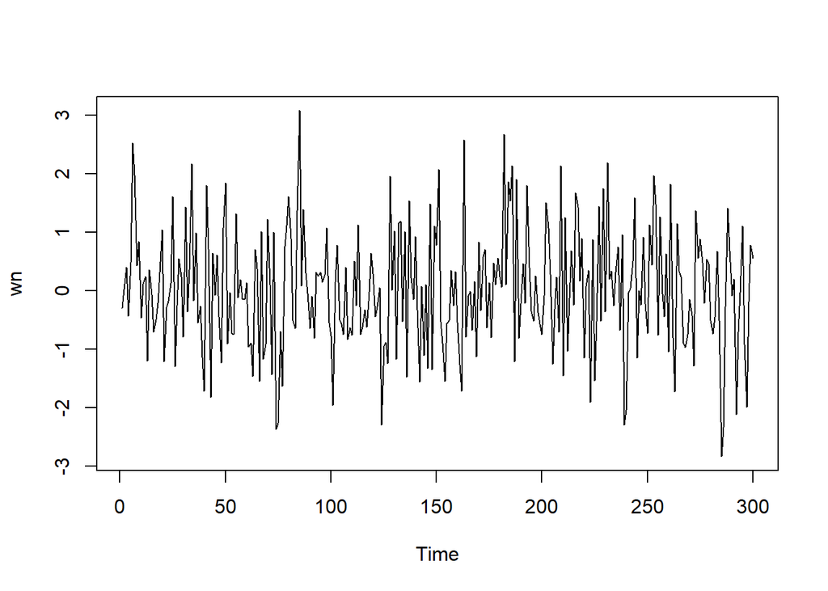

```r
set.seed(1050)
wn <- rnorm(300)
ts.plot(wn)
```

Dapat terlihat bahwa *white noise* tidak memiliki autokorelasi dari ACF. Perhatikan bahwa lag ke-0 adalah korelasi observasi ke-t dengan dirinya sendiri. Nilai korelasi tersebut pasti 1. Sebagai alternatif, lag pertama di plot ACF dapat ditetapkan sebagai 1 (alih-alih 0) dengan menambahkan argumen `xlim(1, lag akhir)`. Plot tersebut dapat disandingkan bersamaan dengan membuat matriks $1 \times 2$ dengan `par(mfrow = c(1,2))`.

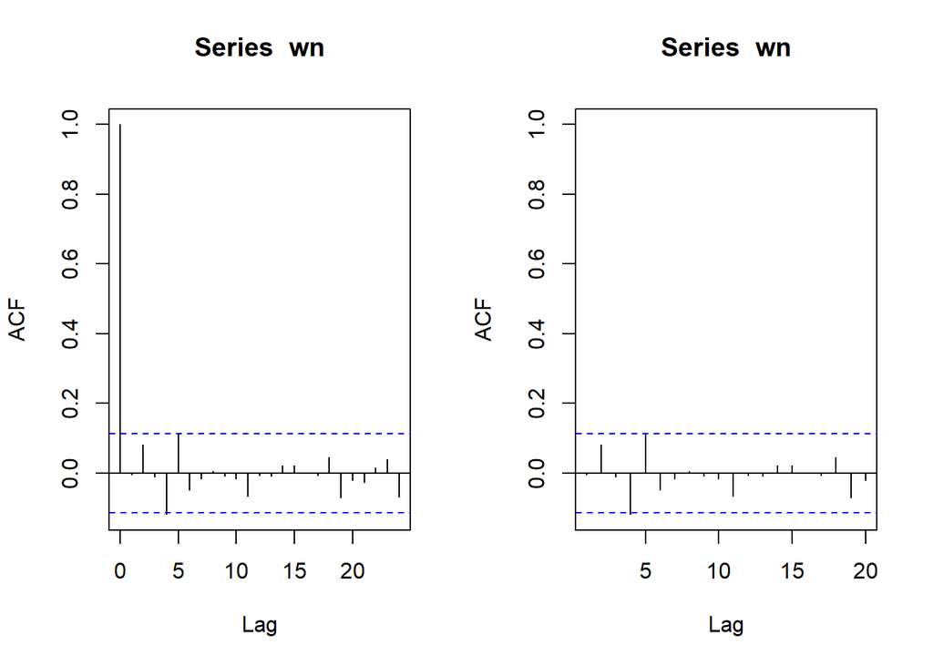

```r
par(mfrow = c(1, 2))
acf(wn)
acf(wn, xlim = c(1, 20))
```

# Proses MA

Proses MA dapat dituliskan sebagai berikut:

$$y_{t} = c + e_t + \theta_{1}e_{t-1} + \theta_{2}e_{t-2} + \dots + \theta_{q}e_{t-q} = c+{e_t+\sum_{i=1}^p \theta_ie_{t-i}}$$
## Pembangkitan Proses MA(2)

### Bangkitan Manual

```r
set.seed(1050)
MA<- wn[c(1,2)]
MA
```

```
[1] -0.29581307  0.02599988
```

Persamaan MA(2) adalah sebagai berikut:

$$y_t = e_t+0.4e_{t-1}+0.6e_{t-2}$$

```r
set.seed(1050)
for(i in 3:300){
   MA[i] <- wn[i] + 0.4 * wn[i - 1] +  0.6 * wn[i - 2]
}
MA
```

```
  [1] -0.2958130686  0.0259998836  0.2309638702 -0.2517039000  0.5487383428
  [6]  2.4602377720  3.2770914012  2.7388121449  2.2072402034  0.1390588882
 [11]  0.4449799225  0.0158842059 -1.0251118082  0.0233227257 -0.6343118837
 [16] -0.5168228150 -0.8123527496 -0.8346404669  0.1121713806  1.1100875986
 [21] -0.4930433920 -0.1433063037 -1.0162357452 -0.1116623202  1.5503030132
 [26] -0.5746027598  0.1913638626 -0.3311587208  0.3056970353 -0.3612800543
 [31]  1.2551907858 -0.2550774151  1.0683512202  2.0928838585  0.9070489475
 [36]  2.2167540101 -0.2587823987  0.1048372908 -1.5690946422 -2.3311158265
 [41]  0.4324112422  0.3990332770 -0.4572014674  0.3424690867 -0.9112946731
 [46]  0.9688350014 -0.2469242891 -1.0409877088  0.3119385697  1.5313181512
 [51]  0.4702624340  0.7097717680 -1.2860211876 -1.0545260063  0.5809220764
 [56] -0.0343250055  0.9305411305 -0.1275975223 -0.0835176471 -0.0005934039
 [61] -0.9901881209 -1.1996626833 -2.4017779571 -0.4217996003 -0.2146096919
 [66] -0.9657844876  0.6269368225 -1.6821913035 -0.7749330765  0.1582708376
 [71]  0.0448233851 -0.6516487385  0.4942479068 -2.8191016637 -2.6092104266
```

[output cut: 45 more lines]

### Bangkitan arima.sim

```r
set.seed(1050)
MA2 <- arima.sim(list(order=c(0,0,2), ma=c(0.4,0.6)), n=300)
MA2
```

```
Time Series:
Start = 1
End = 300
Frequency = 1
  [1]  0.2309638702 -0.2517039000  0.5487383428  2.4602377720  3.2770914012
  [6]  2.7388121449  2.2072402034  0.1390588882  0.4449799225  0.0158842059
 [11] -1.0251118082  0.0233227257 -0.6343118837 -0.5168228150 -0.8123527496
 [16] -0.8346404669  0.1121713806  1.1100875986 -0.4930433920 -0.1433063037
 [21] -1.0162357452 -0.1116623202  1.5503030132 -0.5746027598  0.1913638626
 [26] -0.3311587208  0.3056970353 -0.3612800543  1.2551907858 -0.2550774151
 [31]  1.0683512202  2.0928838585  0.9070489475  2.2167540101 -0.2587823987
 [36]  0.1048372908 -1.5690946422 -2.3311158265  0.4324112422  0.3990332770
 [41] -0.4572014674  0.3424690867 -0.9112946731  0.9688350014 -0.2469242891
 [46] -1.0409877088  0.3119385697  1.5313181512  0.4702624340  0.7097717680
 [51] -1.2860211876 -1.0545260063  0.5809220764 -0.0343250055  0.9305411305
```

[output cut: 49 more lines]

## Karakteristik MA(2)

### Plot Time Series

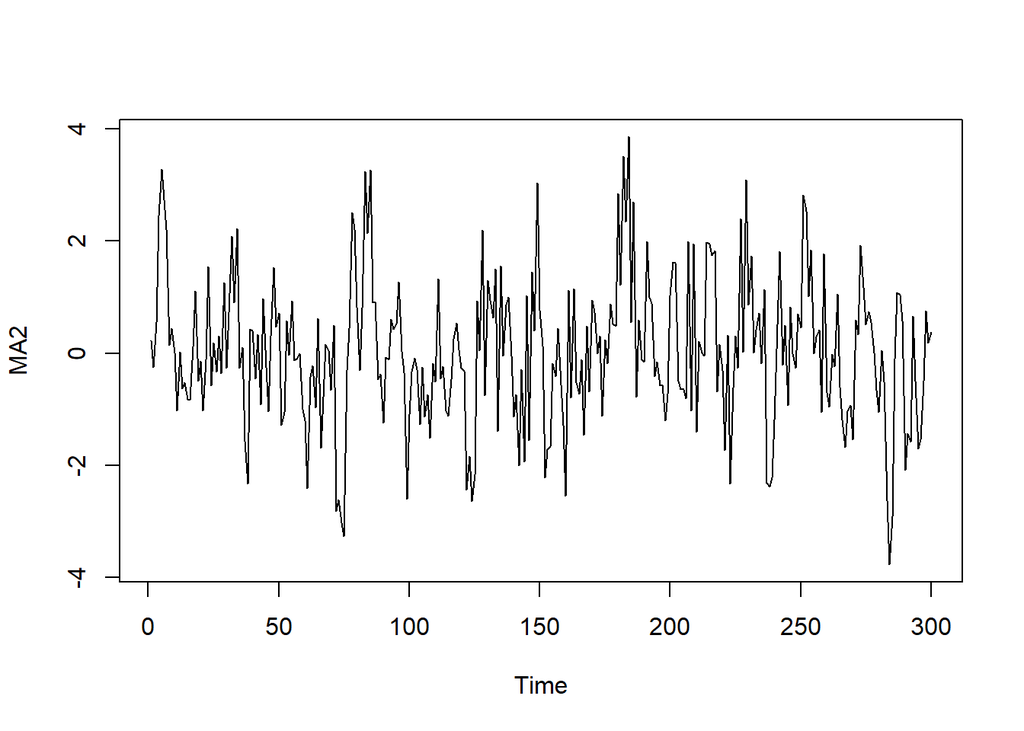

```r
ts.plot(MA2)
```

Berdasarkan plot time series, terlihat bahwa data MA(2) yang dibangkitkan stasioner dalam rataan

### Plot ACF

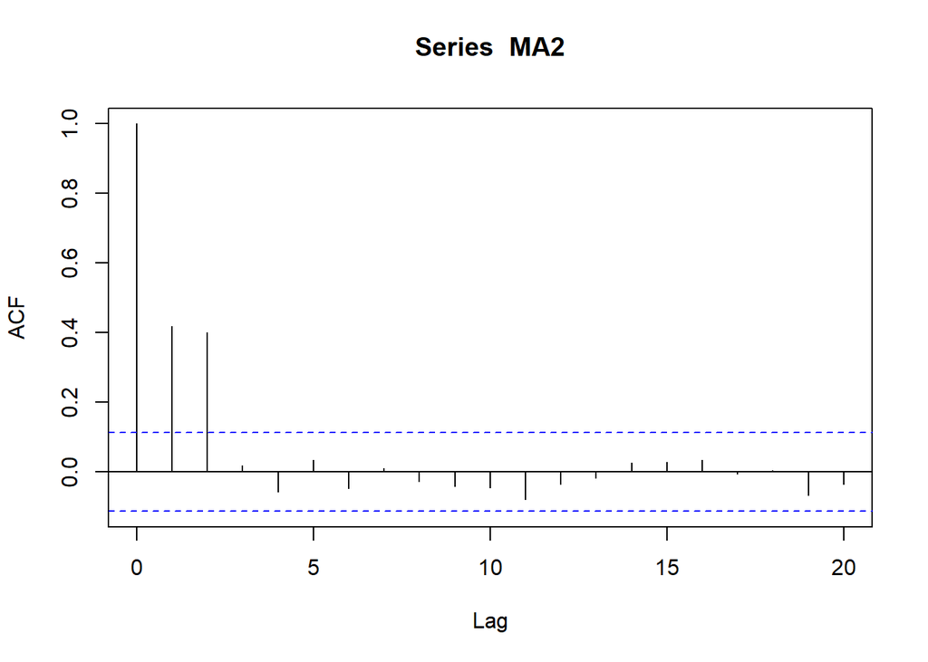

```r
acf(MA2,lag.max = 20)
```

Berdasarkan plot ACF tersebut, terlihat bahwa plot ACF cuts off di lag kedua

### Plot PACF

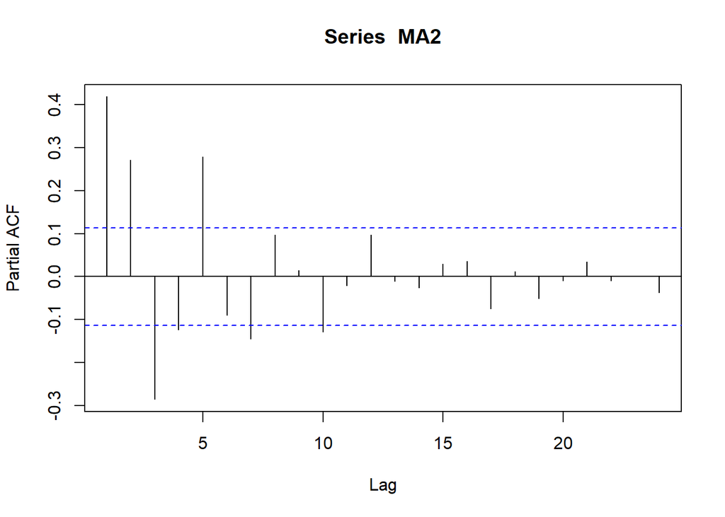

```r
pacf(MA2)
```

Berdasarkan plot PACF tersebut, terlihat bahwa plot PACF cenderung tails off dan membentuk gelombang sinus

### Plot EACF

```r
TSA::eacf(MA2)
```

```
AR/MA
  0 1 2 3 4 5 6 7 8 9 10 11 12 13
0 x x o o o o o o o o o  o  o  o
1 x x o o o o o o o o o  o  o  o
2 x x x x o o o o o o o  o  o  o
3 x x x x o o o o o o o  o  o  o
4 x x o x o o o o o o o  o  o  o
5 x x o x o o o o o o o  o  o  o
6 x x x x x o x o o o o  o  o  o
7 x x x x o o x o o o o  o  o  o
```

Berdasarkan pola segitiga nol pada plot EACF, terlihat bahwa segitiga nol berada pada ordo AR(0) dan ordo MA(2)

## Scatterplot Antar Lag

### Korelasi antara $Y_t$ dengan $Y_{t−1}$

```r
#Yt
yt_MA2 <- MA2[-1]
yt_MA2
```

```
  [1] -0.2517039000  0.5487383428  2.4602377720  3.2770914012  2.7388121449
  [6]  2.2072402034  0.1390588882  0.4449799225  0.0158842059 -1.0251118082
 [11]  0.0233227257 -0.6343118837 -0.5168228150 -0.8123527496 -0.8346404669
 [16]  0.1121713806  1.1100875986 -0.4930433920 -0.1433063037 -1.0162357452
 [21] -0.1116623202  1.5503030132 -0.5746027598  0.1913638626 -0.3311587208
 [26]  0.3056970353 -0.3612800543  1.2551907858 -0.2550774151  1.0683512202
 [31]  2.0928838585  0.9070489475  2.2167540101 -0.2587823987  0.1048372908
 [36] -1.5690946422 -2.3311158265  0.4324112422  0.3990332770 -0.4572014674
 [41]  0.3424690867 -0.9112946731  0.9688350014 -0.2469242891 -1.0409877088
 [46]  0.3119385697  1.5313181512  0.4702624340  0.7097717680 -1.2860211876
 [51] -1.0545260063  0.5809220764 -0.0343250055  0.9305411305 -0.1275975223
 [56] -0.0835176471 -0.0005934039 -0.9901881209 -1.1996626833 -2.4017779571
 [61] -0.4217996003 -0.2146096919 -0.9657844876  0.6269368225 -1.6821913035
 [66] -0.7749330765  0.1582708376  0.0448233851 -0.6516487385  0.4942479068
 [71] -2.8191016637 -2.6092104266 -3.0144480397 -3.2612892605 -0.3060376893
```

[output cut: 45 more lines]

```r
#Yt-1
yt_1_MA2 <- MA2[-300]
yt_1_MA2
```

```
  [1]  0.2309638702 -0.2517039000  0.5487383428  2.4602377720  3.2770914012
  [6]  2.7388121449  2.2072402034  0.1390588882  0.4449799225  0.0158842059
 [11] -1.0251118082  0.0233227257 -0.6343118837 -0.5168228150 -0.8123527496
 [16] -0.8346404669  0.1121713806  1.1100875986 -0.4930433920 -0.1433063037
 [21] -1.0162357452 -0.1116623202  1.5503030132 -0.5746027598  0.1913638626
 [26] -0.3311587208  0.3056970353 -0.3612800543  1.2551907858 -0.2550774151
 [31]  1.0683512202  2.0928838585  0.9070489475  2.2167540101 -0.2587823987
 [36]  0.1048372908 -1.5690946422 -2.3311158265  0.4324112422  0.3990332770
 [41] -0.4572014674  0.3424690867 -0.9112946731  0.9688350014 -0.2469242891
 [46] -1.0409877088  0.3119385697  1.5313181512  0.4702624340  0.7097717680
 [51] -1.2860211876 -1.0545260063  0.5809220764 -0.0343250055  0.9305411305
 [56] -0.1275975223 -0.0835176471 -0.0005934039 -0.9901881209 -1.1996626833
 [61] -2.4017779571 -0.4217996003 -0.2146096919 -0.9657844876  0.6269368225
 [66] -1.6821913035 -0.7749330765  0.1582708376  0.0448233851 -0.6516487385
 [71]  0.4942479068 -2.8191016637 -2.6092104266 -3.0144480397 -3.2612892605
```

[output cut: 45 more lines]

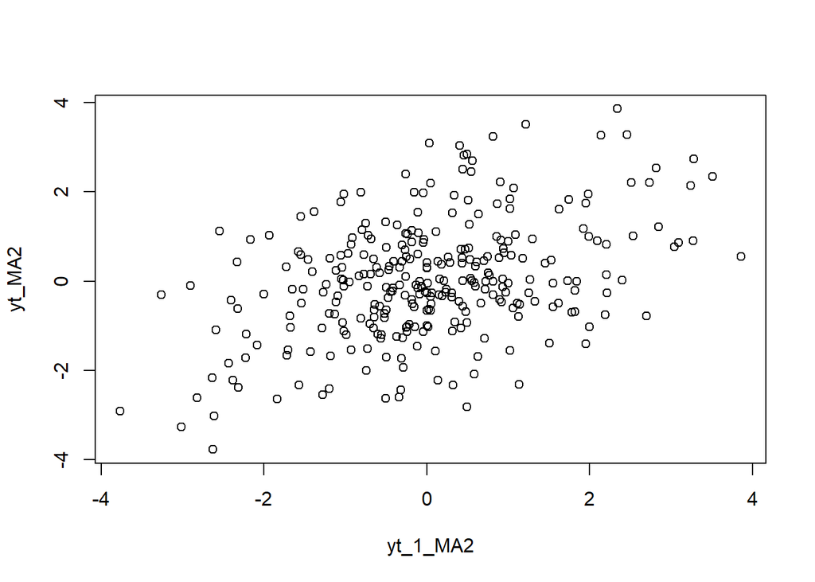

```r
plot(y=yt_MA2,x=yt_1_MA2)
```

Berdasarkan scatterplot tersebut, terlihat bahwa terdapat hubungan positif antara $Y_t$ dengan $Y_{t-1}$. Hal ini sesuai dengan teori yang ada

```r
cor(yt_MA2,yt_1_MA2)
```

```
[1] 0.4189233
```

Korelasi antara $Y_t$ dengan $Y_{t-1}$ dari hasil simulasi mendekati perhitungan teoritis yaitu

$$\rho_1 = \frac{-\theta_1 + \theta_1 \theta_2}{1 + \theta_1^2 + \theta_2^2}
= \frac{-(-0.4) + (0.4)(0.6)}{1 + (0.4)^2 + (0.6)^2}
= \frac{0.64}{1.52}
= 0.42$$

### Korelasi antara $Y_t$ dengan $Y_{t-2}$

```r
#Yt
yt_MA2 <- MA2[-c(1,2)]
yt_MA2
```

```
  [1]  0.5487383428  2.4602377720  3.2770914012  2.7388121449  2.2072402034
  [6]  0.1390588882  0.4449799225  0.0158842059 -1.0251118082  0.0233227257
 [11] -0.6343118837 -0.5168228150 -0.8123527496 -0.8346404669  0.1121713806
 [16]  1.1100875986 -0.4930433920 -0.1433063037 -1.0162357452 -0.1116623202
 [21]  1.5503030132 -0.5746027598  0.1913638626 -0.3311587208  0.3056970353
 [26] -0.3612800543  1.2551907858 -0.2550774151  1.0683512202  2.0928838585
 [31]  0.9070489475  2.2167540101 -0.2587823987  0.1048372908 -1.5690946422
 [36] -2.3311158265  0.4324112422  0.3990332770 -0.4572014674  0.3424690867
 [41] -0.9112946731  0.9688350014 -0.2469242891 -1.0409877088  0.3119385697
 [46]  1.5313181512  0.4702624340  0.7097717680 -1.2860211876 -1.0545260063
 [51]  0.5809220764 -0.0343250055  0.9305411305 -0.1275975223 -0.0835176471
 [56] -0.0005934039 -0.9901881209 -1.1996626833 -2.4017779571 -0.4217996003
 [61] -0.2146096919 -0.9657844876  0.6269368225 -1.6821913035 -0.7749330765
 [66]  0.1582708376  0.0448233851 -0.6516487385  0.4942479068 -2.8191016637
 [71] -2.6092104266 -3.0144480397 -3.2612892605 -0.3060376893  0.4435210269
```

[output cut: 45 more lines]

```r
#Yt-2
yt_2_MA2 <- MA2[-c(299,300)]
yt_2_MA2
```

```
  [1]  0.2309638702 -0.2517039000  0.5487383428  2.4602377720  3.2770914012
  [6]  2.7388121449  2.2072402034  0.1390588882  0.4449799225  0.0158842059
 [11] -1.0251118082  0.0233227257 -0.6343118837 -0.5168228150 -0.8123527496
 [16] -0.8346404669  0.1121713806  1.1100875986 -0.4930433920 -0.1433063037
 [21] -1.0162357452 -0.1116623202  1.5503030132 -0.5746027598  0.1913638626
 [26] -0.3311587208  0.3056970353 -0.3612800543  1.2551907858 -0.2550774151
 [31]  1.0683512202  2.0928838585  0.9070489475  2.2167540101 -0.2587823987
 [36]  0.1048372908 -1.5690946422 -2.3311158265  0.4324112422  0.3990332770
 [41] -0.4572014674  0.3424690867 -0.9112946731  0.9688350014 -0.2469242891
 [46] -1.0409877088  0.3119385697  1.5313181512  0.4702624340  0.7097717680
 [51] -1.2860211876 -1.0545260063  0.5809220764 -0.0343250055  0.9305411305
 [56] -0.1275975223 -0.0835176471 -0.0005934039 -0.9901881209 -1.1996626833
 [61] -2.4017779571 -0.4217996003 -0.2146096919 -0.9657844876  0.6269368225
 [66] -1.6821913035 -0.7749330765  0.1582708376  0.0448233851 -0.6516487385
 [71]  0.4942479068 -2.8191016637 -2.6092104266 -3.0144480397 -3.2612892605
```

[output cut: 45 more lines]

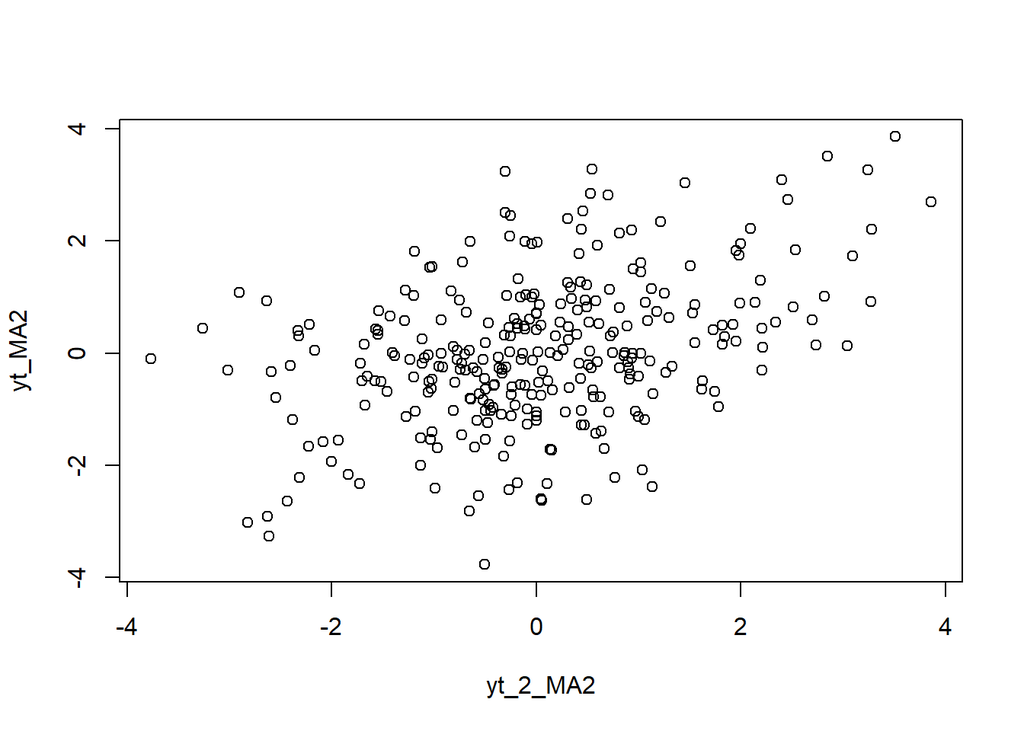

```r
plot(y=yt_MA2,x=yt_2_MA2)
```

Berdasarkan scatterplot tersebut, terlihat bahwa terdapat hubungan positif antara $Y_t$ dengan $Y_{t-2}$. Hal ini sesuai dengan teori yang ada

```r
cor(yt_MA2,yt_2_MA2)
```

```
[1] 0.3997803
```

Korelasi antara $Y_t$ dengan $Y_{t-2}$ dari hasil simulasi mendekati perhitungan teoritis yaitu

$$\rho_2 = \frac{-\theta_2}{1 + \theta_1^2 + \theta_2^2}
= \frac{-(-0.6)}{1 + (0.4)^2 + (0.6)^2}
= \frac{0.6}{1.52}
= 0.3947$$

### Korelasi antara $Y_t$ dengan $Y_{t-3}$

```r
#Yt
yt_MA2 <- MA2[-c(1,2,3)]
yt_MA2
```

```
  [1]  2.4602377720  3.2770914012  2.7388121449  2.2072402034  0.1390588882
  [6]  0.4449799225  0.0158842059 -1.0251118082  0.0233227257 -0.6343118837
 [11] -0.5168228150 -0.8123527496 -0.8346404669  0.1121713806  1.1100875986
 [16] -0.4930433920 -0.1433063037 -1.0162357452 -0.1116623202  1.5503030132
 [21] -0.5746027598  0.1913638626 -0.3311587208  0.3056970353 -0.3612800543
 [26]  1.2551907858 -0.2550774151  1.0683512202  2.0928838585  0.9070489475
 [31]  2.2167540101 -0.2587823987  0.1048372908 -1.5690946422 -2.3311158265
 [36]  0.4324112422  0.3990332770 -0.4572014674  0.3424690867 -0.9112946731
 [41]  0.9688350014 -0.2469242891 -1.0409877088  0.3119385697  1.5313181512
 [46]  0.4702624340  0.7097717680 -1.2860211876 -1.0545260063  0.5809220764
 [51] -0.0343250055  0.9305411305 -0.1275975223 -0.0835176471 -0.0005934039
 [56] -0.9901881209 -1.1996626833 -2.4017779571 -0.4217996003 -0.2146096919
 [61] -0.9657844876  0.6269368225 -1.6821913035 -0.7749330765  0.1582708376
 [66]  0.0448233851 -0.6516487385  0.4942479068 -2.8191016637 -2.6092104266
 [71] -3.0144480397 -3.2612892605 -0.3060376893  0.4435210269  2.5115362136
```

[output cut: 45 more lines]

```r
#Yt-3
yt_3_MA2 <- MA2[-c(298,299,300)]
yt_3_MA2
```

```
  [1]  0.2309638702 -0.2517039000  0.5487383428  2.4602377720  3.2770914012
  [6]  2.7388121449  2.2072402034  0.1390588882  0.4449799225  0.0158842059
 [11] -1.0251118082  0.0233227257 -0.6343118837 -0.5168228150 -0.8123527496
 [16] -0.8346404669  0.1121713806  1.1100875986 -0.4930433920 -0.1433063037
 [21] -1.0162357452 -0.1116623202  1.5503030132 -0.5746027598  0.1913638626
 [26] -0.3311587208  0.3056970353 -0.3612800543  1.2551907858 -0.2550774151
 [31]  1.0683512202  2.0928838585  0.9070489475  2.2167540101 -0.2587823987
 [36]  0.1048372908 -1.5690946422 -2.3311158265  0.4324112422  0.3990332770
 [41] -0.4572014674  0.3424690867 -0.9112946731  0.9688350014 -0.2469242891
 [46] -1.0409877088  0.3119385697  1.5313181512  0.4702624340  0.7097717680
 [51] -1.2860211876 -1.0545260063  0.5809220764 -0.0343250055  0.9305411305
 [56] -0.1275975223 -0.0835176471 -0.0005934039 -0.9901881209 -1.1996626833
 [61] -2.4017779571 -0.4217996003 -0.2146096919 -0.9657844876  0.6269368225
 [66] -1.6821913035 -0.7749330765  0.1582708376  0.0448233851 -0.6516487385
 [71]  0.4942479068 -2.8191016637 -2.6092104266 -3.0144480397 -3.2612892605
```

[output cut: 45 more lines]

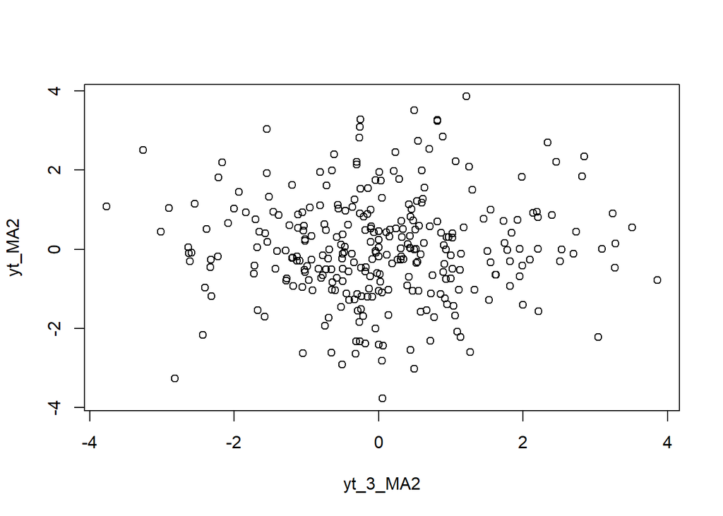

```r
plot(y=yt_MA2,x=yt_3_MA2)
```

Berdasarkan scatterplot tersebut, terlihat bahwa cenderung tidak terdapat hubungan antara $Y_t$ dengan $Y_{t-3}$.

```r
cor(yt_MA2,yt_3_MA2)
```

```
[1] 0.01763368
```

Korelasi antara $Y_t$ dengan $Y_{t-3}$ hasil simulasi mendekati teori yang ada yaitu 0.

# Proses AR

Proses AR dapat dituliskan sebagai berikut:

$$y_{t} = c + e_t + \phi_{1}Y_{t-1} + \phi_{2}Y_{t-2} + \dots + \phi_{q}Y_{t-q} = c+{e_t+\sum_{i=1}^p \phi_iY_{t-i}}$$

Terlihat bahwa $Y_t$ berperan penting dalam pembangkitan proses AR.

## Pembangkitan Proses AR

### Bangkitan Manual

Persamaan AR(2) adalah sebagai berikut:

$$Y_t = e_t+0.5Y_{t-1}+0.2Y_{t-2}$$

```r
set.seed(1050)
n<-length(wn)
n
```

```
[1] 300
```

```r
AR <- c(2:n)
for (i in 3:n) {AR[i]<-wn[i]+0.5*AR[i-1]+0.2*AR[i-2]}
AR
```

```
  [1]  2.000000000  3.000000000  2.298051758  1.322501346  1.601378126
  [6]  3.589134983  4.094045997  3.197613597  3.264229033  1.812392749
 [11]  1.679752077  1.445501528 -0.136095342  0.576405805  0.201408595
 [16] -0.490219163 -0.698953620 -0.660788033  0.023769051  0.920193435
 [21] -0.740751746 -0.471682490 -0.562727854 -0.244661059  1.370252922
 [26] -0.659083739 -0.309093640  0.261085446  0.307602838 -0.579282492
 [31]  1.197863202  0.128784735  0.658442047  2.518645234  1.219906845
 [36]  2.100677794  0.743402246  0.524843986 -0.720644310 -1.973574866
 [41]  0.667831602  0.649667851 -1.362236769  0.093258864 -0.302507857
 [46]  0.480242613 -0.266428500 -1.267441003  0.384671419  1.779659777
 [51]  0.057695127  0.353691544 -0.539759773 -0.943756971  0.735824536
 [56]  0.065343114  0.366511713  0.062347513 -0.037455911  0.130307127
 [61] -0.901992765 -1.322674930 -2.308624898 -0.715247500 -0.435265067
 [66] -1.902259947 -0.025065196 -1.555476259 -1.700558251  0.061514296
 [71] -0.203002337 -1.517121118  0.202444705 -2.565192142 -3.507084887
```

[output cut: 45 more lines]

### Bangkitan arima.sim

```r
set.seed(1050)
aR2 <- arima.sim(list(order=c(2,0,0), ar=c(0.5,0.2)), n=300)
aR2
```

```
Time Series:
Start = 1
End = 300
Frequency = 1
  [1] -0.663197739 -0.312229938  0.258694498  0.305780104 -0.580672049
  [6]  1.196803877  0.127977162  0.657826395  2.518175893  1.219549044
 [11]  2.100405025  0.743194302  0.524685460 -0.720765162 -1.973666997
 [16]  0.667761366  0.649614307 -1.362277588  0.093227746 -0.302531580
 [21]  0.480224527 -0.266442287 -1.267451514  0.384663407  1.779653669
 [26]  0.057690470  0.353687994 -0.539762479 -0.943759034  0.735822963
 [31]  0.065341915  0.366510799  0.062346816 -0.037456442  0.130306722
 [36] -0.901993074 -1.322675165 -2.308625077 -0.715247637 -0.435265172
 [41] -1.902260027 -0.025065257 -1.555476306 -1.700558286  0.061514269
 [46] -0.203002358 -1.517121134  0.202444693 -2.565192151 -3.507084894
 [51] -2.957243652 -3.806076301 -1.735711907 -0.513437678  1.006156595
```

[output cut: 49 more lines]

## Karakteristik AR(2)

### Plot Time Series

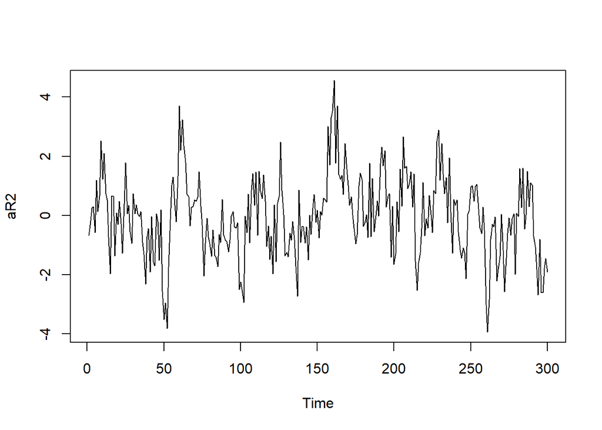

```r
ts.plot(aR2)
```

Berdasarkan plot time series tersebut terlihat bahwa data cenderung stasioner pada rataan

### Plot ACF

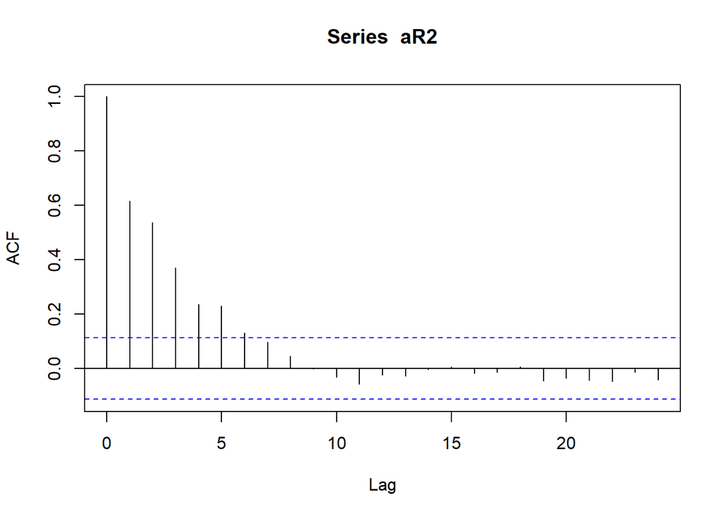

```r
acf(aR2)
```

Berdasarkan plot ACF tersebut terlihat bahwa plot ACF cenderung tails off

### Plot PACF

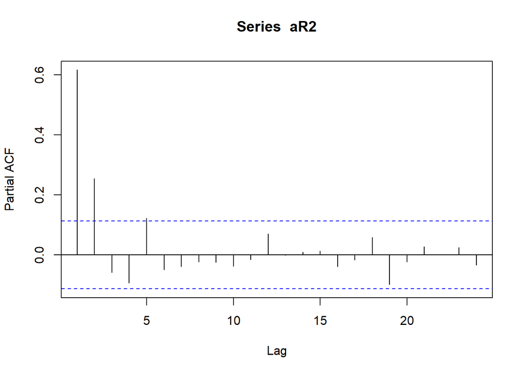

```r
pacf(aR2)
```

Berdasarkan plot PACF tersebut, terlihat bahwa plot PACF cuts off pada lag kedua, sejalan dengan teori yang ada

### Plot EACF

```r
TSA::eacf(aR2)
```

```
AR/MA
  0 1 2 3 4 5 6 7 8 9 10 11 12 13
0 x x x x x x o o o o o  o  o  o
1 x x o x x o o o o o o  o  o  o
2 x x o x o o o o o o o  o  o  o
3 x x o o x o o o o o o  o  o  o
4 x x x o o o o o o o o  o  o  o
5 x x o x o o o o o o o  o  o  o
6 x o x o x o o x o o o  o  o  o
7 x x o o o x o x o o o  o  o  o
```

Berdasarkan pola segitiga nol pada plot EACF, tidak terlihat bahwa segitiga nol berada pada ordo AR(2).

## Scatterplot Antar Lag

### Korelasi antara $Y_t$ dengan $Y_{t-1}$

```r
#Yt
yt_aR2 <- aR2[-1]
yt_aR2
```

```
  [1] -0.312229938  0.258694498  0.305780104 -0.580672049  1.196803877
  [6]  0.127977162  0.657826395  2.518175893  1.219549044  2.100405025
 [11]  0.743194302  0.524685460 -0.720765162 -1.973666997  0.667761366
 [16]  0.649614307 -1.362277588  0.093227746 -0.302531580  0.480224527
 [21] -0.266442287 -1.267451514  0.384663407  1.779653669  0.057690470
 [26]  0.353687994 -0.539762479 -0.943759034  0.735822963  0.065341915
 [31]  0.366510799  0.062346816 -0.037456442  0.130306722 -0.901993074
 [36] -1.322675165 -2.308625077 -0.715247637 -0.435265172 -1.902260027
 [41] -0.025065257 -1.555476306 -1.700558286  0.061514269 -0.203002358
 [46] -1.517121134  0.202444693 -2.565192151 -3.507084894 -2.957243652
 [51] -3.806076301 -1.735711907 -0.513437678  1.006156595  1.293182585
 [56]  0.342931737 -0.207450537  1.334516820  3.703589758  2.204358112
 [61]  3.236783105  2.361556402  1.791291252  0.729844933  0.629191175
 [66] -0.353943450  0.266079797  0.315930889  0.530233550  0.480388636
 [71]  0.620923755  1.477392077  0.313597576 -0.312141237 -2.048432968
```

[output cut: 45 more lines]

```r
#Yt-1
yt_1_aR2 <- aR2[-300]
yt_1_aR2
```

```
  [1] -0.663197739 -0.312229938  0.258694498  0.305780104 -0.580672049
  [6]  1.196803877  0.127977162  0.657826395  2.518175893  1.219549044
 [11]  2.100405025  0.743194302  0.524685460 -0.720765162 -1.973666997
 [16]  0.667761366  0.649614307 -1.362277588  0.093227746 -0.302531580
 [21]  0.480224527 -0.266442287 -1.267451514  0.384663407  1.779653669
 [26]  0.057690470  0.353687994 -0.539762479 -0.943759034  0.735822963
 [31]  0.065341915  0.366510799  0.062346816 -0.037456442  0.130306722
 [36] -0.901993074 -1.322675165 -2.308625077 -0.715247637 -0.435265172
 [41] -1.902260027 -0.025065257 -1.555476306 -1.700558286  0.061514269
 [46] -0.203002358 -1.517121134  0.202444693 -2.565192151 -3.507084894
 [51] -2.957243652 -3.806076301 -1.735711907 -0.513437678  1.006156595
 [56]  1.293182585  0.342931737 -0.207450537  1.334516820  3.703589758
 [61]  2.204358112  3.236783105  2.361556402  1.791291252  0.729844933
 [66]  0.629191175 -0.353943450  0.266079797  0.315930889  0.530233550
 [71]  0.480388636  0.620923755  1.477392077  0.313597576 -0.312141237
```

[output cut: 45 more lines]

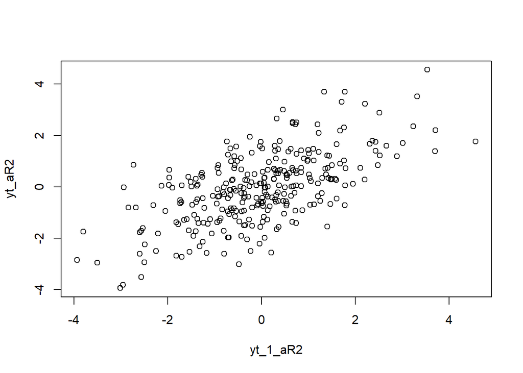

```r
plot(y=yt_aR2,x=yt_1_aR2)
```

Berdasarkan scatterplot tersebut, terlihat bahwa terdapat hubungan positif antara $Y_t$ dengan $Y_{t-1}$. Hal ini sesuai dengan teori yang ada

```r
cor(yt_aR2,yt_1_aR2)
```

```
[1] 0.6190588
```

Korelasi antara $Y_t$ dengan $Y_{t-1}$ dari hasil simulasi mendekati perhitungan teoritis yaitu

$$\text{(Yule--Walker)}\qquad
\rho_1 = \frac{\phi_1}{1-\phi_2}
= \frac{0.5}{1-0.2} = \frac{0.5}{0.8} = 0.625$$

### Korelasi antara $Y_t$ dengan $Y_{t-2}$

```r
#Yt
yt2_aR2 <- aR2[-c(1,2)]
yt2_aR2
```

```
  [1]  0.258694498  0.305780104 -0.580672049  1.196803877  0.127977162
  [6]  0.657826395  2.518175893  1.219549044  2.100405025  0.743194302
 [11]  0.524685460 -0.720765162 -1.973666997  0.667761366  0.649614307
 [16] -1.362277588  0.093227746 -0.302531580  0.480224527 -0.266442287
 [21] -1.267451514  0.384663407  1.779653669  0.057690470  0.353687994
 [26] -0.539762479 -0.943759034  0.735822963  0.065341915  0.366510799
 [31]  0.062346816 -0.037456442  0.130306722 -0.901993074 -1.322675165
 [36] -2.308625077 -0.715247637 -0.435265172 -1.902260027 -0.025065257
 [41] -1.555476306 -1.700558286  0.061514269 -0.203002358 -1.517121134
 [46]  0.202444693 -2.565192151 -3.507084894 -2.957243652 -3.806076301
 [51] -1.735711907 -0.513437678  1.006156595  1.293182585  0.342931737
 [56] -0.207450537  1.334516820  3.703589758  2.204358112  3.236783105
 [61]  2.361556402  1.791291252  0.729844933  0.629191175 -0.353943450
 [66]  0.266079797  0.315930889  0.530233550  0.480388636  0.620923755
 [71]  1.477392077  0.313597576 -0.312141237 -2.048432968 -0.938659801
```

[output cut: 45 more lines]

```r
#Yt-2
yt_2_aR2 <- aR2[-c(299,300)]
yt_2_aR2
```

```
  [1] -0.663197739 -0.312229938  0.258694498  0.305780104 -0.580672049
  [6]  1.196803877  0.127977162  0.657826395  2.518175893  1.219549044
 [11]  2.100405025  0.743194302  0.524685460 -0.720765162 -1.973666997
 [16]  0.667761366  0.649614307 -1.362277588  0.093227746 -0.302531580
 [21]  0.480224527 -0.266442287 -1.267451514  0.384663407  1.779653669
 [26]  0.057690470  0.353687994 -0.539762479 -0.943759034  0.735822963
 [31]  0.065341915  0.366510799  0.062346816 -0.037456442  0.130306722
 [36] -0.901993074 -1.322675165 -2.308625077 -0.715247637 -0.435265172
 [41] -1.902260027 -0.025065257 -1.555476306 -1.700558286  0.061514269
 [46] -0.203002358 -1.517121134  0.202444693 -2.565192151 -3.507084894
 [51] -2.957243652 -3.806076301 -1.735711907 -0.513437678  1.006156595
 [56]  1.293182585  0.342931737 -0.207450537  1.334516820  3.703589758
 [61]  2.204358112  3.236783105  2.361556402  1.791291252  0.729844933
 [66]  0.629191175 -0.353943450  0.266079797  0.315930889  0.530233550
 [71]  0.480388636  0.620923755  1.477392077  0.313597576 -0.312141237
```

[output cut: 45 more lines]

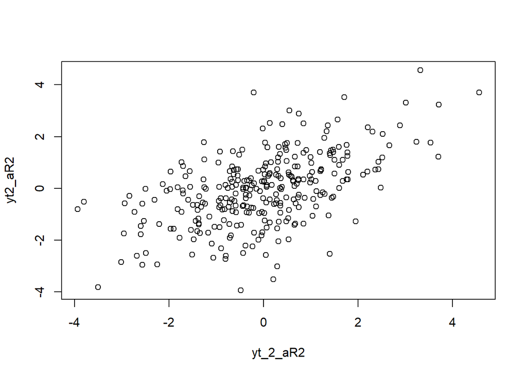

```r
plot(y=yt2_aR2,x=yt_2_aR2)
```

Berdasarkan scatterplot tersebut, terlihat bahwa terdapat hubungan positif antara $Y_t$ dengan $Y_{t-2}$. Hal ini sesuai dengan teori yang ada

```r
cor(yt2_aR2,yt_2_aR2)
```

```
[1] 0.5409336
```

$$\rho_2 = \phi_1 \rho_1 + \phi_2
= \frac{\phi_1^2}{1-\phi_2} + \phi_2
= \frac{\phi_2(1-\phi_2) + \phi_1^2}{1-\phi_2}
= \frac{0.5^2}{1-0.2} + 0.2
= \frac{0.25}{0.8} + 0.2
= 0.3125 + 0.2
= 0.5125$$

### Korelasi antara $Y_t$ dengan $Y_{t-3}$

```r
#Yt
yt3_aR2 <- aR2[-c(1,2,3)]
yt3_aR2
```

```
  [1]  0.305780104 -0.580672049  1.196803877  0.127977162  0.657826395
  [6]  2.518175893  1.219549044  2.100405025  0.743194302  0.524685460
 [11] -0.720765162 -1.973666997  0.667761366  0.649614307 -1.362277588
 [16]  0.093227746 -0.302531580  0.480224527 -0.266442287 -1.267451514
 [21]  0.384663407  1.779653669  0.057690470  0.353687994 -0.539762479
 [26] -0.943759034  0.735822963  0.065341915  0.366510799  0.062346816
 [31] -0.037456442  0.130306722 -0.901993074 -1.322675165 -2.308625077
 [36] -0.715247637 -0.435265172 -1.902260027 -0.025065257 -1.555476306
 [41] -1.700558286  0.061514269 -0.203002358 -1.517121134  0.202444693
 [46] -2.565192151 -3.507084894 -2.957243652 -3.806076301 -1.735711907
 [51] -0.513437678  1.006156595  1.293182585  0.342931737 -0.207450537
 [56]  1.334516820  3.703589758  2.204358112  3.236783105  2.361556402
 [61]  1.791291252  0.729844933  0.629191175 -0.353943450  0.266079797
 [66]  0.315930889  0.530233550  0.480388636  0.620923755  1.477392077
 [71]  0.313597576 -0.312141237 -2.048432968 -0.938659801 -0.097382937
```

[output cut: 45 more lines]

```r
#Yt-3
yt_3_aR2 <- aR2[-c(298,299,300)]
yt_3_aR2
```

```
  [1] -0.663197739 -0.312229938  0.258694498  0.305780104 -0.580672049
  [6]  1.196803877  0.127977162  0.657826395  2.518175893  1.219549044
 [11]  2.100405025  0.743194302  0.524685460 -0.720765162 -1.973666997
 [16]  0.667761366  0.649614307 -1.362277588  0.093227746 -0.302531580
 [21]  0.480224527 -0.266442287 -1.267451514  0.384663407  1.779653669
 [26]  0.057690470  0.353687994 -0.539762479 -0.943759034  0.735822963
 [31]  0.065341915  0.366510799  0.062346816 -0.037456442  0.130306722
 [36] -0.901993074 -1.322675165 -2.308625077 -0.715247637 -0.435265172
 [41] -1.902260027 -0.025065257 -1.555476306 -1.700558286  0.061514269
 [46] -0.203002358 -1.517121134  0.202444693 -2.565192151 -3.507084894
 [51] -2.957243652 -3.806076301 -1.735711907 -0.513437678  1.006156595
 [56]  1.293182585  0.342931737 -0.207450537  1.334516820  3.703589758
 [61]  2.204358112  3.236783105  2.361556402  1.791291252  0.729844933
 [66]  0.629191175 -0.353943450  0.266079797  0.315930889  0.530233550
 [71]  0.480388636  0.620923755  1.477392077  0.313597576 -0.312141237
```

[output cut: 45 more lines]

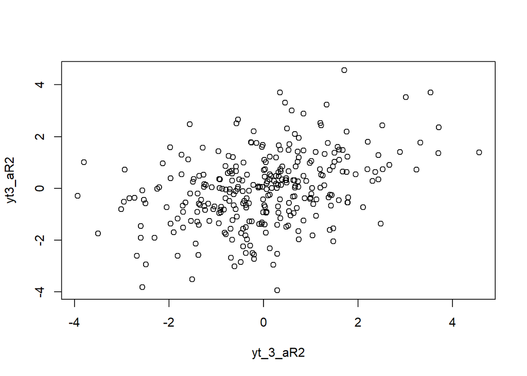

```r
plot(y=yt3_aR2,x=yt_3_aR2)
```

Berdasarkan scatterplot tersebut, terlihat bahwa terdapat hubungan positif antara $Y_t$ dengan $Y_{t-3}$. Hal ini sesuai dengan teori yang ada

```r
cor(yt3_aR2,yt_3_aR2)
```

```
[1] 0.3734324
```

Korelasi antara $Y_t$ dengan $Y_{t-3}$ dari hasil simulasi mendekati perhitungan teoritis yaitu

$$\rho_3 = \phi_1 \rho_2 + \phi_2 \rho_1
= (0.5)(0.5125) + (0.2)(0.625)
= 0.25625 + 0.125
= 0.38125$$

# Proses ARMA

## Fungsi pembangkitan ARMA

bentuk umum data berpola ARMA.

$$y_{t} = c + \sum_{i=1}^p \phi_{i}y_{t-i} + \sum_{j=1}^q e_{t-j}+ e_{t}$$

```r
set.seed(1050)
coefs <- c(0.5, 0.2)
e <- c(1, 2)

coefs %*% e
```

```
     [,1]
[1,]  0.9
```

```r
coefs * e
```

```
[1] 0.5 0.4
```

```r
sum(coefs * e)
```

```
[1] 0.9
```

```r
arma.sim <- function(n, macoef, arcoef){
  manum <- length(macoef)
  arnum <- length(arcoef)
  stopifnot(manum < n & arnum < n)

  wn <- rnorm(n, sd = 0.5)
  init <- max(manum, arnum)

  arma <- wn[1:init]
  for(i in {init+1}:n){
   mastart <- i - manum
   maend <- i-1
   arstart <- i - arnum
   arend <- i-1
   arma[i] <- sum(arcoef * arma[arstart:arend]) + sum(macoef * wn[mastart:maend])  + wn[i]
   }
  return(arma)
}
```

```r
#contoh untuk ARMA
arma22 <- arma.sim(300, c(0.5, 0.2), c(0.4,0.6))

arma22 |> arima(c(2,0,2))
```

```
Call:
arima(x = arma22, order = c(2, 0, 2))

Coefficients:
         ar1     ar2    ma1     ma2  intercept
      0.5766  0.3866  0.234  0.6459     1.8866
s.e.  0.0736  0.0732  0.061  0.0460     1.3393

sigma^2 estimated as 0.2568:  log likelihood = -224.2,  aic = 460.39
```

### Bangkitan Manual

Persamaan ARMA(2,2) sebagai berikut:

$$\text{Model:}\qquad
Y_t = 0.5 Y_{t-1} + 0.2 Y_{t-2} + e_t + 0.4e_{t-1} + 0.6e_{t-2}.$$

```r
set.seed(1050)
n = length(wn)
phi1 = 0.5
theta1 = 0.4
phi2=0.2
theta2=0.6

y.arma=c(1:n)
for (i in 3:n){y.arma[i] = phi1*y.arma[i-1] + theta1*wn[i-1] + phi2*y.arma[i-2] + theta2*wn[i-2]+wn[i]}
y.arma
```

```
  [1]  1.00000000  2.00000000  1.43096387  0.86377804  1.26682013  3.26640345
  [7]  5.16365715  5.97392141  6.22693234  4.44730934  3.91402106  2.86235660
 [13]  1.18887071  1.19022940  0.19857696 -0.17948846 -0.86238159 -1.30172895
 [19] -0.71116941  0.49415710 -0.38819872 -0.23857424 -1.21316261 -0.76595848
 [25]  0.92469125 -0.26544883  0.24357770 -0.26245964  0.22318276 -0.30218060
 [31]  1.14873704  0.25885498  1.42752612  2.85841791  2.62176313  4.09931916
 [37]  2.31522981  2.08231602 -0.06489067 -1.94709796 -0.55411587 -0.26744425
 [43] -0.70174677 -0.06189315 -1.08259060  0.41516107 -0.25586187 -1.08588643
 [49] -0.28217702  1.17305235  1.00035321  1.44455884 -0.36367112 -0.94744980
 [55]  0.03446295 -0.20658349  0.83414198  0.24815677  0.20738913  0.15273252
 [61] -0.87234404 -1.60528820 -3.37889086 -2.43230267 -2.10653920 -2.50551462
 [67] -1.04712833 -2.70685839 -2.33778794 -1.55199481 -1.19873161 -1.56141350
 [73] -0.52620517 -3.39448695 -4.41169493 -5.89919290 -7.09322470 -5.03248862
 [79] -3.49136822 -0.24064562  1.38758262  1.46389873  0.70563171  1.45729565
 [85]  4.11292616  4.48650411  6.34068021  4.97888451  4.67798368  2.86329528
```

[output cut: 35 more lines]

### Bangkitan arima.sim

```r
set.seed(1050)
arma22 <- arima.sim(list(order=c(2,0,2), ar = c(0.5,0.2), ma = c(0.4,0.6)), n=300)
arma22
```

```
Time Series:
Start = 1
End = 300
Frequency = 1
  [1] -0.26391207  0.22207550 -0.30302472  1.14809353  0.25836440  1.42715213
  [7]  2.85813280  2.62154577  4.09915346  2.31510349  2.08221973 -0.06496408
 [13] -1.94715392 -0.55415854 -0.26747678 -0.70177156 -0.06191205 -1.08260501
 [19]  0.41515009 -0.25587025 -1.08589282 -0.28218189  1.17304864  1.00035038
 [25]  1.44455669 -0.36367277 -0.94745105  0.03446200 -0.20658422  0.83414142
 [31]  0.24815634  0.20738881  0.15273227 -0.87234422 -1.60528834 -3.37889097
 [37] -2.43230275 -2.10653926 -2.50551467 -1.04712837 -2.70685842 -2.33778796
 [43] -1.55199483 -1.19873162 -1.56141351 -0.52620517 -3.39448695 -4.41169494
 [49] -5.89919290 -7.09322470 -5.03248862 -3.49136822 -0.24064562  1.38758262
 [55]  1.46389873  0.70563171  1.45729565  4.11292616  4.48650411  6.34068021
 [61]  4.97888451  4.67798368  2.86329528  1.99590390  0.33563998  0.50201712
```

[output cut: 39 more lines]

## Karakteristik ARMA(2,2)

### Plot Time Series

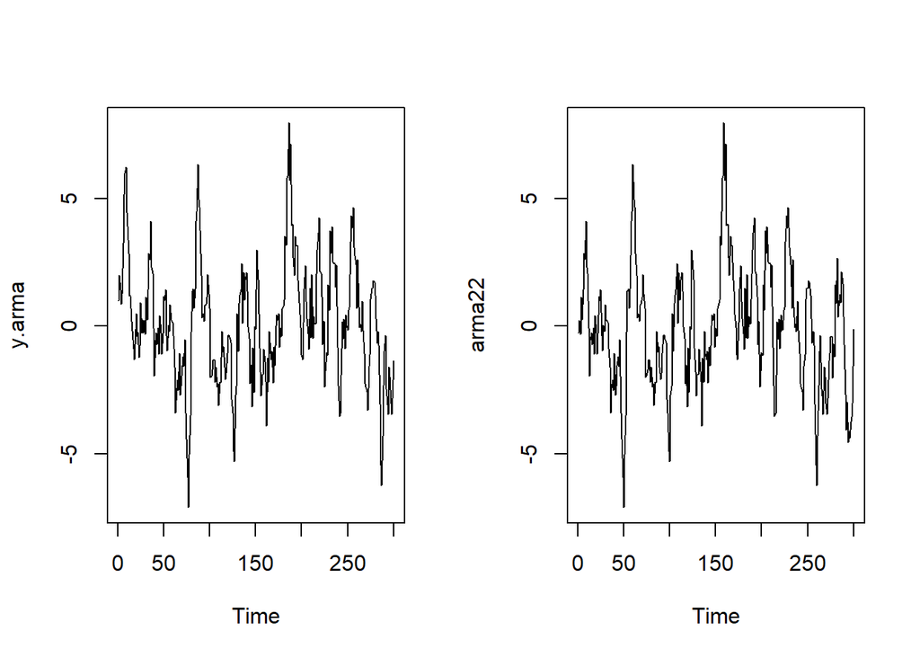

```r
par(mfrow = c(1, 2))
ts.plot(y.arma)
ts.plot(arma22)
```

```r
par(mfrow = c(1, 1))
```

Berdasarkan plot time series tersebut, terlihat bahwa model ARMA(2,2) cenderung stasioner dalam rataan

### Plot ACF

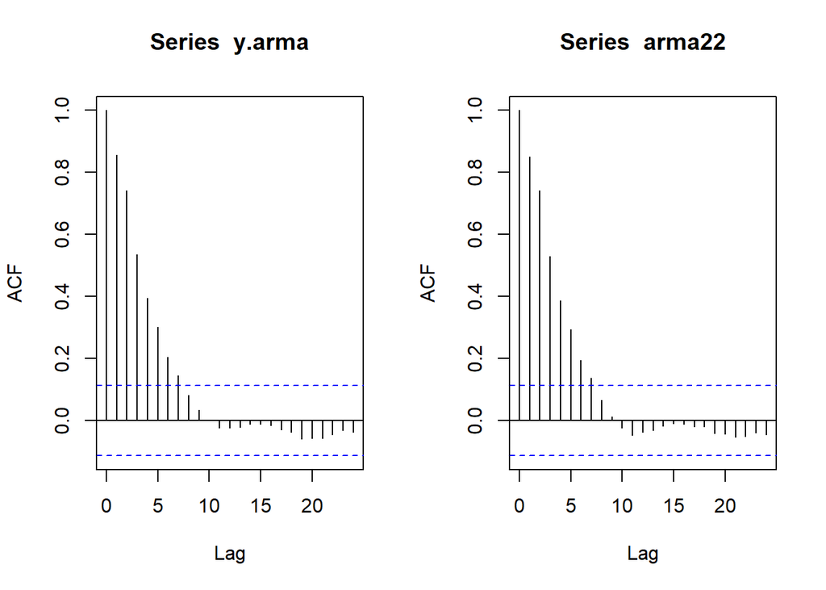

```r
par(mfrow = c(1, 2))
acf(y.arma)
acf(arma22)
```

```r
par(mfrow = c(2, 2))
```

Berdasarkan plot ACF tersebut, terlihat bahwa model ARMA(2,2) hasil simulasi memiliki plot ACF yang tails off, sesuai dengan teori yang ada

### Plot PACF

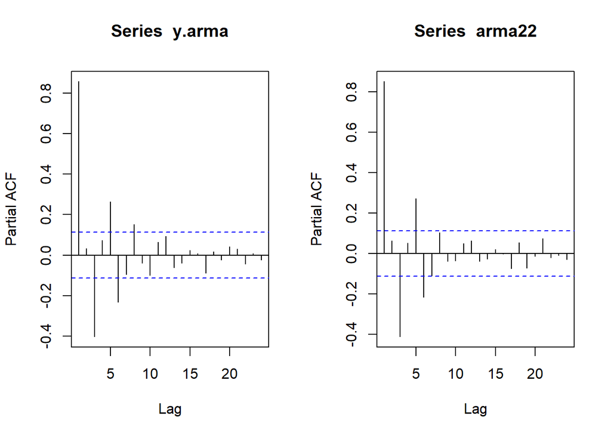

```r
par(mfrow = c(1, 2))
pacf(y.arma)
pacf(arma22)
```

```r
par(mfrow = c(2, 2))
```

Berdasarkan plot PACF tersebut, terlihat bahwa model ARMA(2,2) hasil simulasi memiliki plot PACF yang tails off, sesuai dengan teori

### Plot EACF

```r
TSA::eacf(y.arma)
```

```
AR/MA
  0 1 2 3 4 5 6 7 8 9 10 11 12 13
0 x x x x x x x o o o o  o  o  o
1 o x o o o o o o o o o  o  o  o
2 o x x o o o o o o o o  o  o  o
3 x x x o x o o o o o o  o  o  o
4 x x o x o o o o o o o  o  o  o
5 x x o x o x o o o o o  o  o  o
6 x x x o o x o o o o o  o  o  o
7 x x x x o x x o o o o  o  o  o
```

```r
TSA::eacf(arma22)
```

```
AR/MA
  0 1 2 3 4 5 6 7 8 9 10 11 12 13
0 x x x x x x x o o o o  o  o  o
1 o x o o x o o o o o o  o  o  o
2 x x x o o o x o o o o  o  o  o
3 x x x o x o x o o o o  o  o  o
4 x x x x o o x o o o o  o  o  o
5 x x o x o x o o o o o  o  o  o
6 x x x x o x o o o o o  o  o  o
7 x x x x o x x x o o o  o  o  o
```

Berdasarkan pola segitiga nol pada plot EACF, tidak terlihat bahwa segitiga nol berada pada ordo AR(2) dan MA(2).

## Scatterplot Antar Lag

### Korelasi antara $Y_t$ dengan $Y_{t−1}$

```r
#Yt
yt1_arma <- arma22[-1]
yt1_arma
```

```
  [1]  0.22207550 -0.30302472  1.14809353  0.25836440  1.42715213  2.85813280
  [7]  2.62154577  4.09915346  2.31510349  2.08221973 -0.06496408 -1.94715392
 [13] -0.55415854 -0.26747678 -0.70177156 -0.06191205 -1.08260501  0.41515009
 [19] -0.25587025 -1.08589282 -0.28218189  1.17304864  1.00035038  1.44455669
 [25] -0.36367277 -0.94745105  0.03446200 -0.20658422  0.83414142  0.24815634
 [31]  0.20738881  0.15273227 -0.87234422 -1.60528834 -3.37889097 -2.43230275
 [37] -2.10653926 -2.50551467 -1.04712837 -2.70685842 -2.33778796 -1.55199483
 [43] -1.19873162 -1.56141351 -0.52620517 -3.39448695 -4.41169494 -5.89919290
 [49] -7.09322470 -5.03248862 -3.49136822 -0.24064562  1.38758262  1.46389873
 [55]  0.70563171  1.45729565  4.11292616  4.48650411  6.34068021  4.97888451
 [61]  4.67798368  2.86329528  1.99590390  0.33563998  0.50201712  0.20999674
 [67]  0.81625378  0.88204059  1.13121934  2.01399476  1.27710866  0.69973304
 [73] -1.98513092 -1.94531773 -1.70190664 -1.32991311 -1.29833839 -2.18680582
 [79] -1.59668177 -2.36344085 -2.23181425 -3.10471729 -2.17340074 -2.21104548
 [85] -0.21112084 -0.99305261 -0.77925100 -1.60809806 -2.07624430 -1.82664774
```

[output cut: 35 more lines]

```r
#Yt-1
yt_1_arma <- arma22[-300]
yt_1_arma
```

```
  [1] -0.26391207  0.22207550 -0.30302472  1.14809353  0.25836440  1.42715213
  [7]  2.85813280  2.62154577  4.09915346  2.31510349  2.08221973 -0.06496408
 [13] -1.94715392 -0.55415854 -0.26747678 -0.70177156 -0.06191205 -1.08260501
 [19]  0.41515009 -0.25587025 -1.08589282 -0.28218189  1.17304864  1.00035038
 [25]  1.44455669 -0.36367277 -0.94745105  0.03446200 -0.20658422  0.83414142
 [31]  0.24815634  0.20738881  0.15273227 -0.87234422 -1.60528834 -3.37889097
 [37] -2.43230275 -2.10653926 -2.50551467 -1.04712837 -2.70685842 -2.33778796
 [43] -1.55199483 -1.19873162 -1.56141351 -0.52620517 -3.39448695 -4.41169494
 [49] -5.89919290 -7.09322470 -5.03248862 -3.49136822 -0.24064562  1.38758262
 [55]  1.46389873  0.70563171  1.45729565  4.11292616  4.48650411  6.34068021
 [61]  4.97888451  4.67798368  2.86329528  1.99590390  0.33563998  0.50201712
 [67]  0.20999674  0.81625378  0.88204059  1.13121934  2.01399476  1.27710866
 [73]  0.69973304 -1.98513092 -1.94531773 -1.70190664 -1.32991311 -1.29833839
 [79] -2.18680582 -1.59668177 -2.36344085 -2.23181425 -3.10471729 -2.17340074
 [85] -2.21104548 -0.21112084 -0.99305261 -0.77925100 -1.60809806 -2.07624430
```

[output cut: 35 more lines]

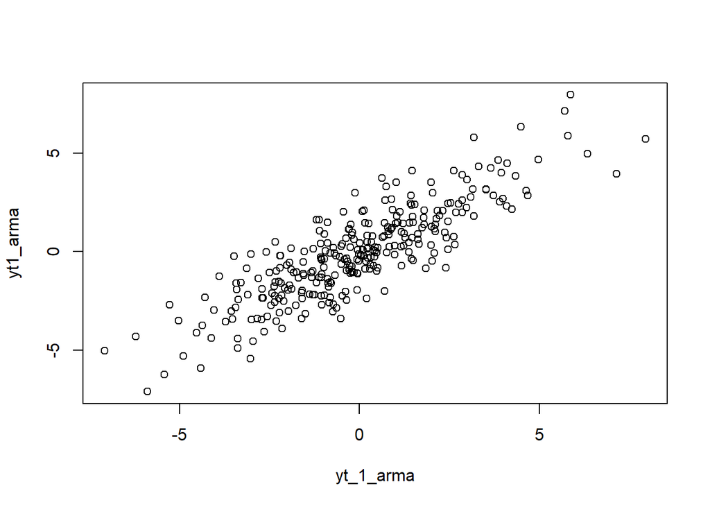

```r
plot(y=yt1_arma,x=yt_1_arma)
```

Berdasarkan scatterplot tersebut, terlihat bahwa terdapat hubungan positif antara $Y_t$ dengan $Y_{t−1}$. Hal ini sesuai dengan teori yang ada

```r
cor(yt1_arma,yt_1_arma)
```

```
[1] 0.8502547
```

Korelasi antara $Y_t$ dengan $Y_{t−1}$ dari hasil simulasi mendekati perhitungan teoritis.

$$\text{Yule--Walker (gammas):}\qquad
\begin{aligned}
\gamma_0 &= \phi_1\gamma_1 + \phi_2\gamma_2 + \sigma^2(1+\theta_1^2+\theta_2^2),\\[6pt]
\gamma_1 &= \phi_1\gamma_0 + \phi_2\gamma_1 + \sigma^2(\theta_1+\theta_1\theta_2),\\[6pt]
\gamma_2 &= \phi_1\gamma_1 + \phi_2\gamma_0 + \sigma^2\theta_2.
\end{aligned}$$

$$\text{Substitusi } \phi_1=0.5,\ \phi_2=0.2,\ \theta_1=0.4,\ \theta_2=0.6,\ \sigma^2=1:$$

$$1+\theta_1^2+\theta_2^2 = 1 + 0.4^2 + 0.6^2 = 1.52,\qquad
\theta_1+\theta_1\theta_2 = 0.4 + 0.4\cdot0.6 = 0.64.$$

$$\begin{aligned}
\gamma_0 &= 0.5\gamma_1 + 0.2\gamma_2 + 1.52,\\[6pt]
\gamma_1 &= 0.5\gamma_0 + 0.2\gamma_1 + 0.64,\\[6pt]
\gamma_2 &= 0.5\gamma_1 + 0.2\gamma_0 + 0.6.
\end{aligned}$$

$$\text{Menyelesaikan sistem di atas (aljabar/numerik) memberi:}$$

$$\gamma_0 \approx 3.6239316239,\qquad
\gamma_1 \approx 3.06495726496,\qquad
\gamma_2 \approx 2.85726495726.$$

$$\text{Autokorelasi:}\qquad
\rho_k = \frac{\gamma_k}{\gamma_0}.$$

$$\rho_1 = \frac{\gamma_1}{\gamma_0} \approx
\frac{3.06495726496}{3.6239316239} \approx 0.845754717$$

### Korelasi antara $Y_t$ dengan $Y_{t−2}$

```r
#Yt
yt2_arma <- arma22[-c(1,2)]
yt2_arma
```

```
  [1] -0.30302472  1.14809353  0.25836440  1.42715213  2.85813280  2.62154577
  [7]  4.09915346  2.31510349  2.08221973 -0.06496408 -1.94715392 -0.55415854
 [13] -0.26747678 -0.70177156 -0.06191205 -1.08260501  0.41515009 -0.25587025
 [19] -1.08589282 -0.28218189  1.17304864  1.00035038  1.44455669 -0.36367277
 [25] -0.94745105  0.03446200 -0.20658422  0.83414142  0.24815634  0.20738881
 [31]  0.15273227 -0.87234422 -1.60528834 -3.37889097 -2.43230275 -2.10653926
 [37] -2.50551467 -1.04712837 -2.70685842 -2.33778796 -1.55199483 -1.19873162
 [43] -1.56141351 -0.52620517 -3.39448695 -4.41169494 -5.89919290 -7.09322470
 [49] -5.03248862 -3.49136822 -0.24064562  1.38758262  1.46389873  0.70563171
 [55]  1.45729565  4.11292616  4.48650411  6.34068021  4.97888451  4.67798368
 [61]  2.86329528  1.99590390  0.33563998  0.50201712  0.20999674  0.81625378
 [67]  0.88204059  1.13121934  2.01399476  1.27710866  0.69973304 -1.98513092
 [73] -1.94531773 -1.70190664 -1.32991311 -1.29833839 -2.18680582 -1.59668177
 [79] -2.36344085 -2.23181425 -3.10471729 -2.17340074 -2.21104548 -0.21112084
 [85] -0.99305261 -0.77925100 -1.60809806 -2.07624430 -1.82664774 -1.06762836
```

[output cut: 35 more lines]

```r
#Yt-1
yt_2_arma <- arma22[-c(299,300)]
yt_2_arma
```

```
  [1] -0.26391207  0.22207550 -0.30302472  1.14809353  0.25836440  1.42715213
  [7]  2.85813280  2.62154577  4.09915346  2.31510349  2.08221973 -0.06496408
 [13] -1.94715392 -0.55415854 -0.26747678 -0.70177156 -0.06191205 -1.08260501
 [19]  0.41515009 -0.25587025 -1.08589282 -0.28218189  1.17304864  1.00035038
 [25]  1.44455669 -0.36367277 -0.94745105  0.03446200 -0.20658422  0.83414142
 [31]  0.24815634  0.20738881  0.15273227 -0.87234422 -1.60528834 -3.37889097
 [37] -2.43230275 -2.10653926 -2.50551467 -1.04712837 -2.70685842 -2.33778796
 [43] -1.55199483 -1.19873162 -1.56141351 -0.52620517 -3.39448695 -4.41169494
 [49] -5.89919290 -7.09322470 -5.03248862 -3.49136822 -0.24064562  1.38758262
 [55]  1.46389873  0.70563171  1.45729565  4.11292616  4.48650411  6.34068021
 [61]  4.97888451  4.67798368  2.86329528  1.99590390  0.33563998  0.50201712
 [67]  0.20999674  0.81625378  0.88204059  1.13121934  2.01399476  1.27710866
 [73]  0.69973304 -1.98513092 -1.94531773 -1.70190664 -1.32991311 -1.29833839
 [79] -2.18680582 -1.59668177 -2.36344085 -2.23181425 -3.10471729 -2.17340074
 [85] -2.21104548 -0.21112084 -0.99305261 -0.77925100 -1.60809806 -2.07624430
```

[output cut: 35 more lines]

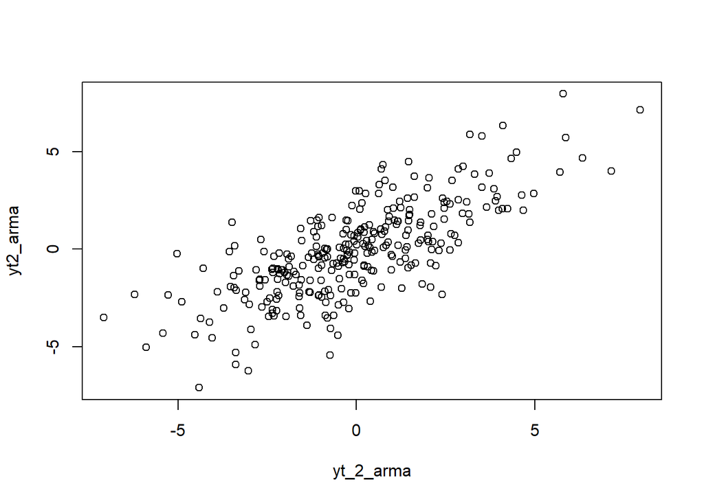

```r
plot(y=yt2_arma,x=yt_2_arma)
```

```r
cor(yt2_arma,yt_2_arma)
```

```
[1] 0.7424757
```

$$\rho_2 = \frac{\gamma_2}{\gamma_0} \approx
\frac{2.85726495726}{3.6239316239} \approx 0.788443396$$

### Korelasi antara $Y_t$ dengan $Y_{t−3}$

```r
#Yt
yt3_arma <- arma22[-c(1,2,3)]
yt3_arma
```

```
  [1]  1.14809353  0.25836440  1.42715213  2.85813280  2.62154577  4.09915346
  [7]  2.31510349  2.08221973 -0.06496408 -1.94715392 -0.55415854 -0.26747678
 [13] -0.70177156 -0.06191205 -1.08260501  0.41515009 -0.25587025 -1.08589282
 [19] -0.28218189  1.17304864  1.00035038  1.44455669 -0.36367277 -0.94745105
 [25]  0.03446200 -0.20658422  0.83414142  0.24815634  0.20738881  0.15273227
 [31] -0.87234422 -1.60528834 -3.37889097 -2.43230275 -2.10653926 -2.50551467
 [37] -1.04712837 -2.70685842 -2.33778796 -1.55199483 -1.19873162 -1.56141351
 [43] -0.52620517 -3.39448695 -4.41169494 -5.89919290 -7.09322470 -5.03248862
 [49] -3.49136822 -0.24064562  1.38758262  1.46389873  0.70563171  1.45729565
 [55]  4.11292616  4.48650411  6.34068021  4.97888451  4.67798368  2.86329528
 [61]  1.99590390  0.33563998  0.50201712  0.20999674  0.81625378  0.88204059
 [67]  1.13121934  2.01399476  1.27710866  0.69973304 -1.98513092 -1.94531773
 [73] -1.70190664 -1.32991311 -1.29833839 -2.18680582 -1.59668177 -2.36344085
 [79] -2.23181425 -3.10471729 -2.17340074 -2.21104548 -0.21112084 -0.99305261
 [85] -0.77925100 -1.60809806 -2.07624430 -1.82664774 -1.06762836 -0.36042352
```

[output cut: 35 more lines]

```r
#Yt-3
yt_3_arma <- arma22[-c(298,299,300)]
yt_3_arma
```

```
  [1] -0.26391207  0.22207550 -0.30302472  1.14809353  0.25836440  1.42715213
  [7]  2.85813280  2.62154577  4.09915346  2.31510349  2.08221973 -0.06496408
 [13] -1.94715392 -0.55415854 -0.26747678 -0.70177156 -0.06191205 -1.08260501
 [19]  0.41515009 -0.25587025 -1.08589282 -0.28218189  1.17304864  1.00035038
 [25]  1.44455669 -0.36367277 -0.94745105  0.03446200 -0.20658422  0.83414142
 [31]  0.24815634  0.20738881  0.15273227 -0.87234422 -1.60528834 -3.37889097
 [37] -2.43230275 -2.10653926 -2.50551467 -1.04712837 -2.70685842 -2.33778796
 [43] -1.55199483 -1.19873162 -1.56141351 -0.52620517 -3.39448695 -4.41169494
 [49] -5.89919290 -7.09322470 -5.03248862 -3.49136822 -0.24064562  1.38758262
 [55]  1.46389873  0.70563171  1.45729565  4.11292616  4.48650411  6.34068021
 [61]  4.97888451  4.67798368  2.86329528  1.99590390  0.33563998  0.50201712
 [67]  0.20999674  0.81625378  0.88204059  1.13121934  2.01399476  1.27710866
 [73]  0.69973304 -1.98513092 -1.94531773 -1.70190664 -1.32991311 -1.29833839
 [79] -2.18680582 -1.59668177 -2.36344085 -2.23181425 -3.10471729 -2.17340074
 [85] -2.21104548 -0.21112084 -0.99305261 -0.77925100 -1.60809806 -2.07624430
```

[output cut: 35 more lines]

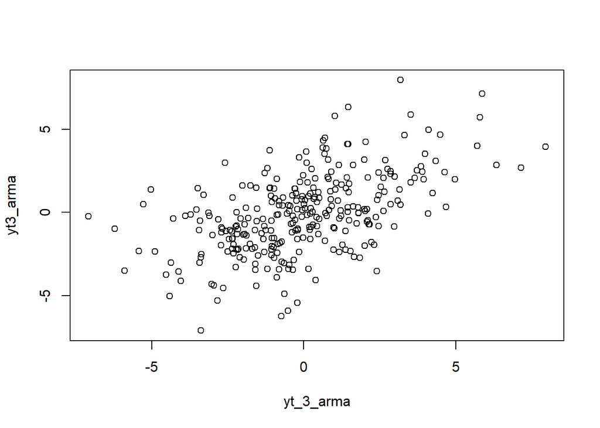

```r
plot(y=yt3_arma,x=yt_3_arma)
```

Berdasarkan scatterplot tersebut, terlihat bahwa terdapat hubungan positif antara $Y_t$ dengan $Y_{t−3}$. Hal ini sesuai dengan teori yang ada

```r
cor(yt3_arma,yt_3_arma)
```

```
[1] 0.5334292
```

$$\rho_3 = \phi_1\rho_2 + \phi_2\rho_1 =
0.5\cdot 0.788443396 + 0.2\cdot 0.845754717
\approx 0.563372642$$